# The Global Value Chain of Cars: a Selective Assessment of Turkish Case and Other Countries

Group5 - Mert Yazal

6/18/2019

## Introduction

**Task:** The Global Value Chain of Turkey and other determined car exporters will be visualized in this project. This project aims to show export relations and export evolution of Turkey and other 7 countries. These countries are USA, Japan, Korea, Germany, Poland, SouthAfrica, Mexico as the former four countries as advanced economies, and the rest as the countries as emergent market economies.

**Dataset:** Car, engine, suspension and tranmission parts sales plotted on a world map that include lattitude and longtitude along with export, import, value added and units by Country, time, HS96 code. All of the product data shown on the project is classified using HS (Harmonized System).[link](https://unstats.un.org/unsd/tradekb/Knowledgebase/50018/Harmonized-Commodity-Description-and-Coding-Systems-HS)

For all of the HS data used throughout the project (1996 - 2015) we use the BACII International Trade Database2. The original data comes from the United Nations Statistical Division, yet is cleaned by the BACI team using their own methodology of harmonization.[link](http://www.cepii.fr/CEPII/fr/publications/wp/abstract.asp?NoDoc=2726)

## The Evolution of Value Added

In the Log-Log scale plots, all the countries increase their export share while EMEs exports are over all more volatile.

### Cars

While advanced economies follow (Germany, Japan, USA) a similar growth path, starting from lower levels, Turkey and Mexico drastically increase their value addition in car exports.

There is a drastic decrease in exports 2008 due to financial crisis. There are more fluctuations in vehicle export than engine, suspension and transmission export since vehicle export, not entirely by producer side, but is also affected by the changes in consumption expenditure.

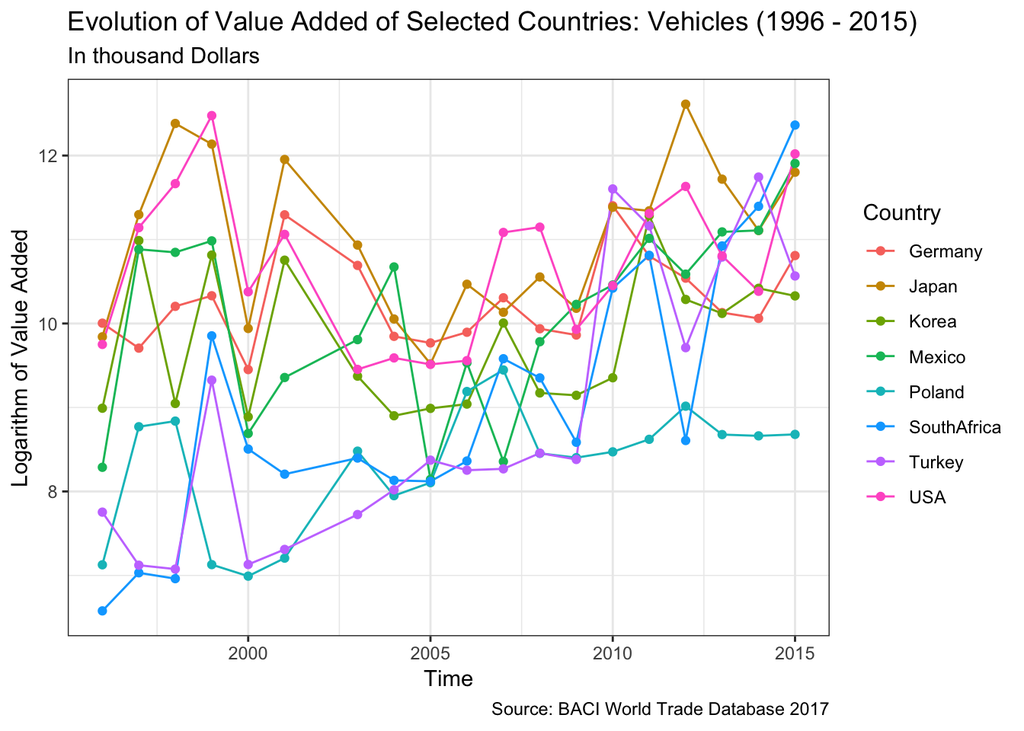

### Engine

All the EMEs increasing their share in engine exports. However, South Africa, since the country has many global customers in automative industry, has increased its share drastically relative to other countries. (Since the year 2002 has been excluded, the transition effect from 2001 to 2003 looks large in the log scale.)

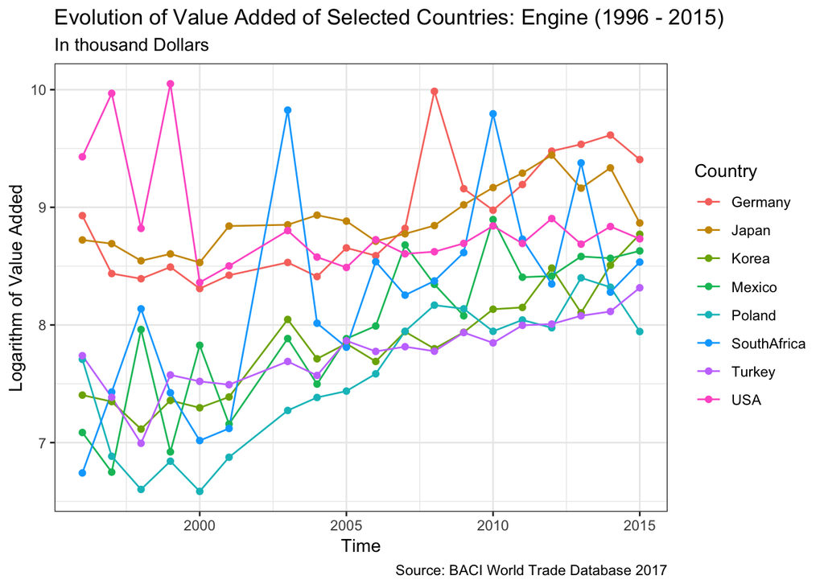

### Suspension

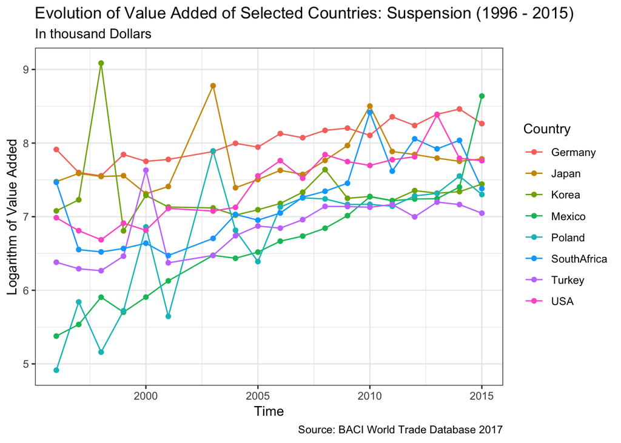

### Transmission

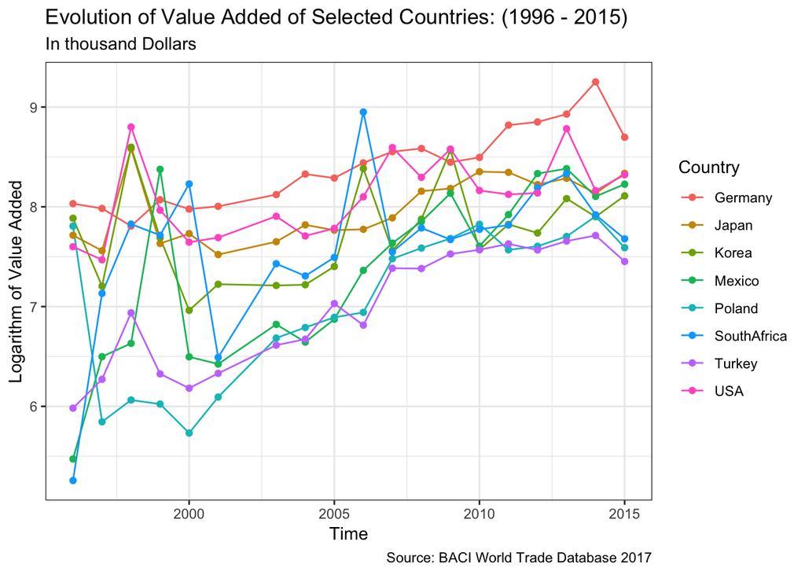

## Relative share in terms of Export Value

Even though EMEs have performed better in terms of increasing their value addition, the total of value of their exports is still small. The chunks of treemap represent the sum of our product bundle value in terms of countries.

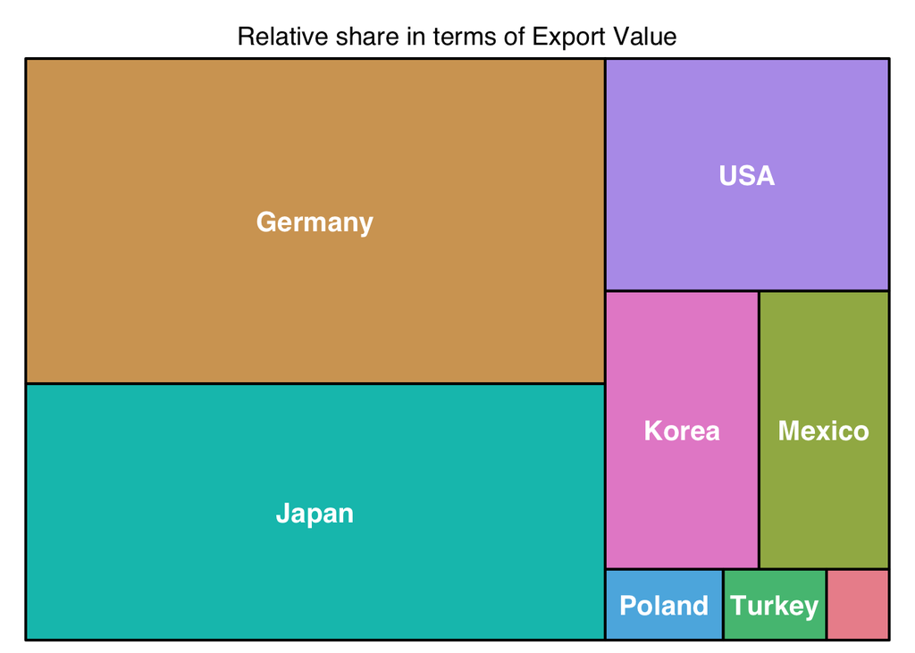

## Turkey - Turkish case

After financial crisis, thanks to larger amounts of FDI and strong inflow of portfolio investments, Turkey has experienced a tremendeous increase in exports, with the penetration of multinational car companies into automative sector.

### Extension of Vehicles and Main Parts, Value Added (1996-2015)

Value added has been affected positevely by foreign subsidies.

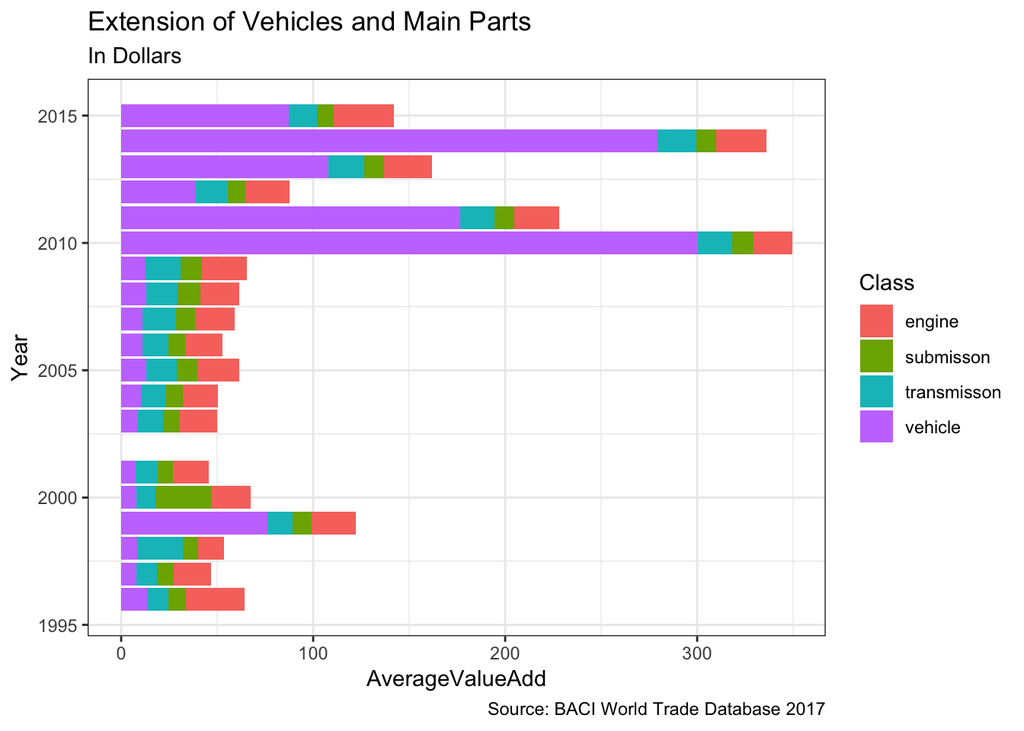

### Turkish Exports to other countries (1996 - 2015)

There is an overall increase in exports after 2009. The big chunk of Turkish goods is exported to Europe. Among the countries set, Germany has the highest share.

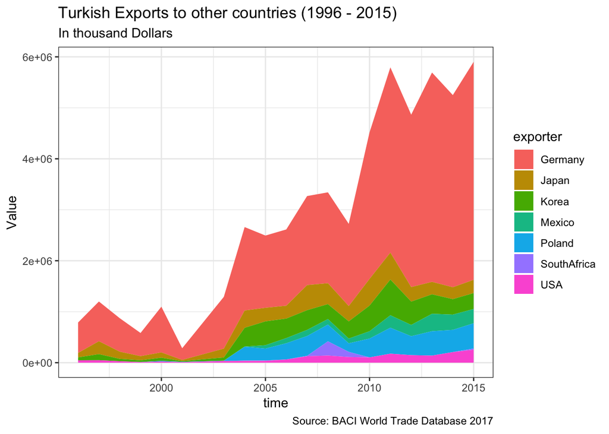

### Turkish Imports to other countries (1996 - 2015)

Turkey has also increased its import position mostly with European countries and overall the world: Germany and Poland dominates the graph.

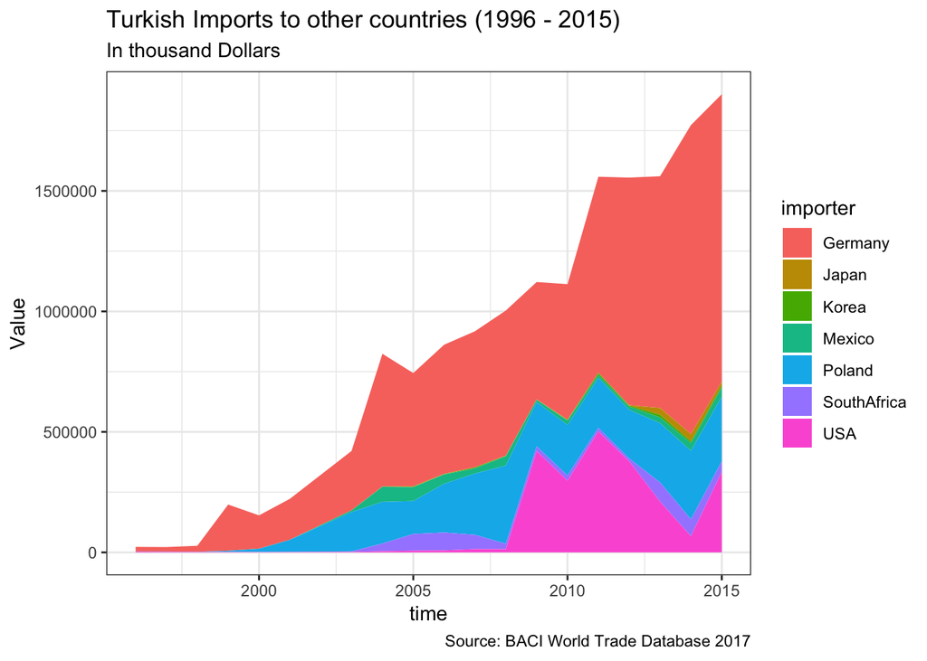

## Export Volume

On the world map, the two types of country sets in terms of export volume, AEs and EMEs, are represented below.

[interactive chart not shown]